# Tarefa 1 - Análise dos Dados

Leonardo Martelli e Marcello Fabrizio

06/09/2021

### 0 - Limpeza do ambiente e carregamento de pacotes

```r
rm(list=ls())

library('ggplot2')
library('gridExtra')
library('GGally')
library(grid)
library(stringr)
```

### 1- Carregue a base de dados e mostre a estrutura do dataset (str()). Comente sobre o número de amostras, de variáveis (e seu tipo). O arquivo do dataset não pode ser modificado de forma alguma. A leitura deverá ser realizada de tal maneira qualquer característica dos dados

```r
beans_data = read.csv("Dry_Bean_Dataset.csv",header=T, sep=";", na.strings="?", dec=",")
str(beans_data)
```

```
## 'data.frame':    13611 obs. of  17 variables:
##  $ Area           : int  28395 28734 29380 30008 30140 30279 30477 30519 30685 30834 ...
##  $ Perimeter      : num  610 638 624 646 620 ...
##  $ MajorAxisLength: num  208 201 213 211 202 ...
##  $ MinorAxisLength: num  174 183 176 183 190 ...
##  $ AspectRation   : num  1.2 1.1 1.21 1.15 1.06 ...
##  $ Eccentricity   : num  0.55 0.412 0.563 0.499 0.334 ...
##  $ ConvexArea     : int  28715 29172 29690 30724 30417 30600 30970 30847 31044 31120 ...
##  $ EquivDiameter  : num  190 191 193 195 196 ...
##  $ Extent         : num  0.764 0.784 0.778 0.783 0.773 ...
##  $ Solidity       : num  0.989 0.985 0.99 0.977 0.991 ...
##  $ roundness      : num  0.958 0.887 0.948 0.904 0.985 ...
##  $ Compactness    : num  0.913 0.954 0.909 0.928 0.971 ...
##  $ ShapeFactor1   : num  0.00733 0.00698 0.00724 0.00702 0.0067 ...
##  $ ShapeFactor2   : num  0.00315 0.00356 0.00305 0.00321 0.00366 ...
##  $ ShapeFactor3   : num  0.834 0.91 0.826 0.862 0.942 ...
##  $ ShapeFactor4   : num  0.999 0.998 0.999 0.994 0.999 ...
##  $ Class          : chr  "SEKER" "SEKER" "SEKER" "SEKER" ...
```

### 2- Altere a variável do tipo do feijão (Class) para um factor. Utilizando um comando mostre como estimar o número de classes existentes.

```r
beans_data$Class = factor(beans_data$Class)

nome_classes = unique(beans_data$Class)

print(levels(nome_classes))
```

```
## [1] "BARBUNYA" "BOMBAY"   "CALI"     "DERMASON" "HOROZ"    "SEKER"    "SIRA"
```

```r
num_classes = length(nome_classes)
```

O conjunto de dados contém 7 classes.

### 3- Quantas amostras existem por classe? Use um gráfico de barras para ilustrar as quantidades.

```r
classes_summary = summary(beans_data$Class)

print(classes_summary)
```

```
## BARBUNYA   BOMBAY     CALI DERMASON    HOROZ    SEKER     SIRA
##     1322      522     1630     3546     1928     2027     2636
```

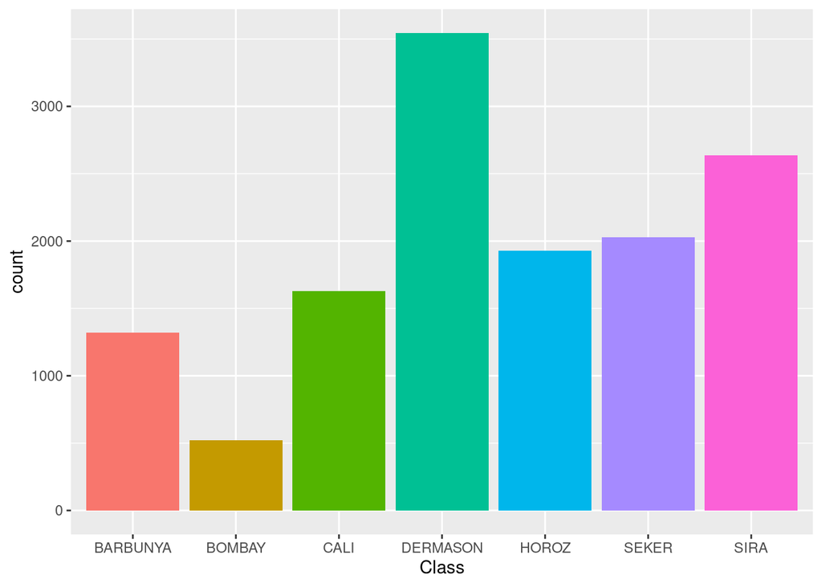

```r
ggplot(beans_data, aes(Class, fill = Class)) + geom_bar() + theme(legend.position = "none")
```

### 4- Alguma variável apresenta outliers? Tem alguma que não apresenta? Se as amostras com outliers fossem removidas, reduziria em quanto o número de amostras? Alguma classe sofreria uma redução maior do que a outra? Crie um boxplot por variável (boxplot()) para auxiliar na explicação. Não remova os outliers para as próximas etapas!

```
## [1] "Coluna Area contém 551 outliers"
## [1] "Coluna Perimeter contém 500 outliers"
## [1] "Coluna MajorAxisLength contém 379 outliers"
## [1] "Coluna MinorAxisLength contém 569 outliers"
## [1] "Coluna AspectRation contém 473 outliers"
## [1] "Coluna Eccentricity contém 843 outliers"
## [1] "Coluna ConvexArea contém 550 outliers"
## [1] "Coluna EquivDiameter contém 526 outliers"
## [1] "Coluna Extent contém 275 outliers"
## [1] "Coluna Solidity contém 778 outliers"
## [1] "Coluna roundness contém 91 outliers"
## [1] "Coluna Compactness contém 109 outliers"
## [1] "Coluna ShapeFactor1 contém 533 outliers"
## [1] "Coluna ShapeFactor3 contém 195 outliers"
## [1] "Coluna ShapeFactor4 contém 767 outliers"
```

Para facilitar a visualização de se as variáveis contêm *outliers*, gráficos do tipo *boxplot* podem auxiliar. Os seguintes gráficos foram gerados em grupos de 4, com exceção da variável *Class*, a qual é o fator de classificação.

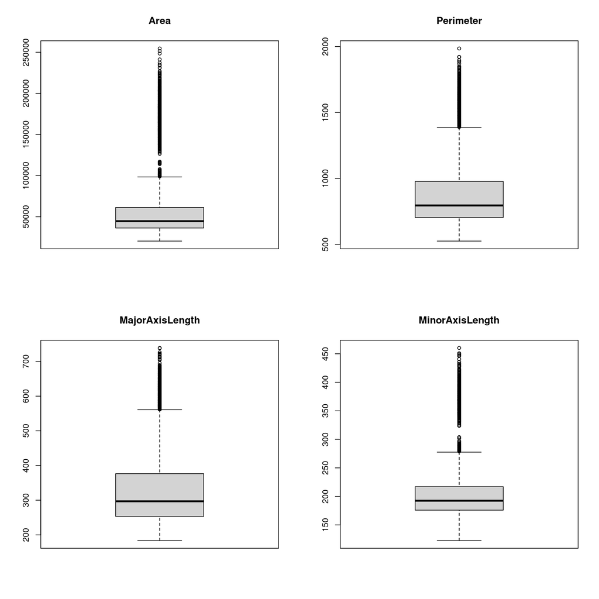

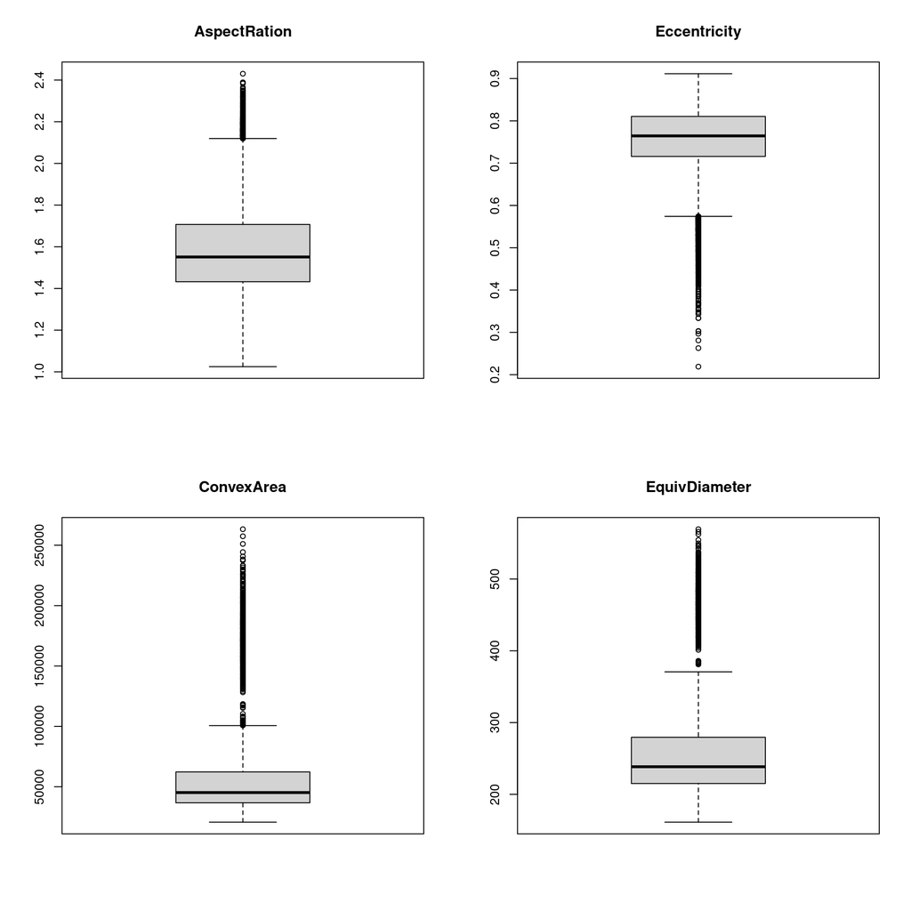

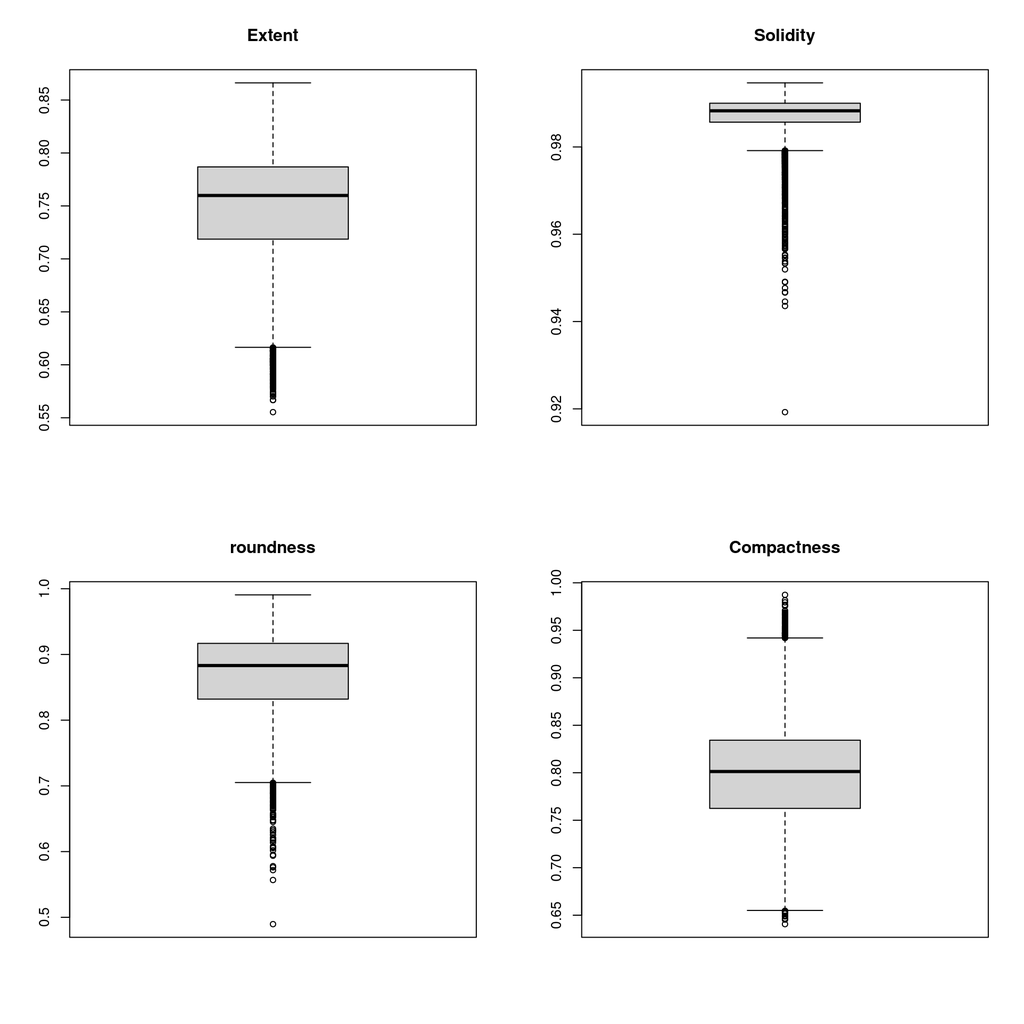

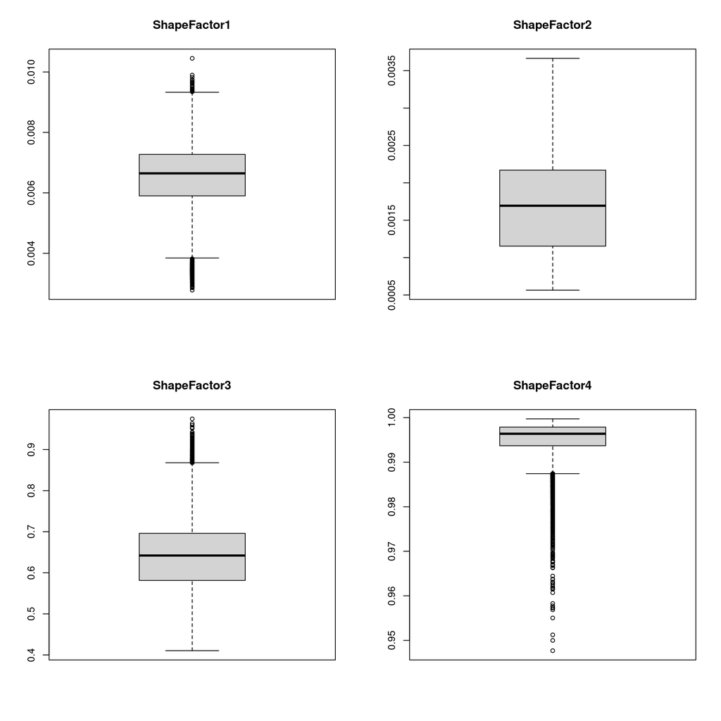

### 5 - Utilizando um gráfico boxplot por variável x classe (organize em 3 colunas), diga qual é a variável que teria maior poder de discriminação? Justifique a sua escolha.

[figure not shown]

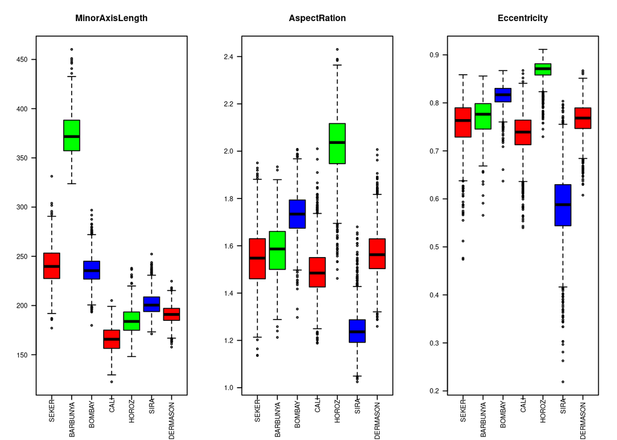

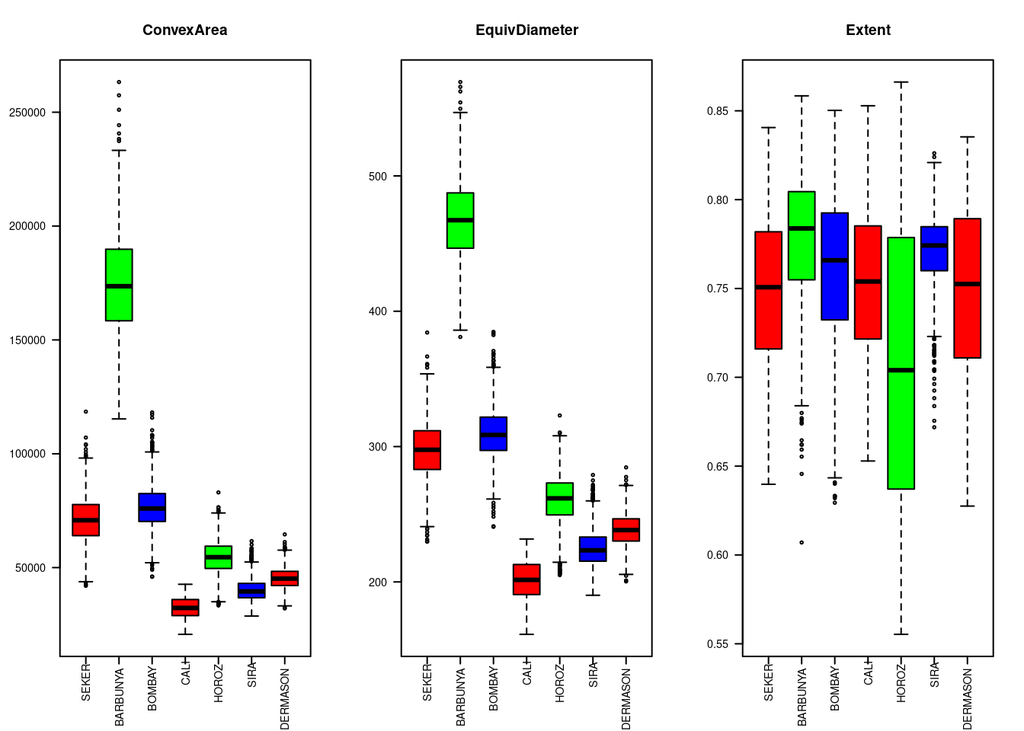

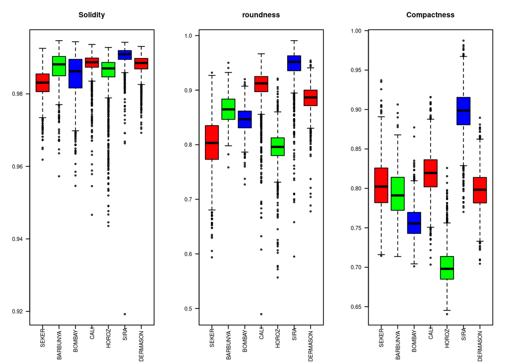

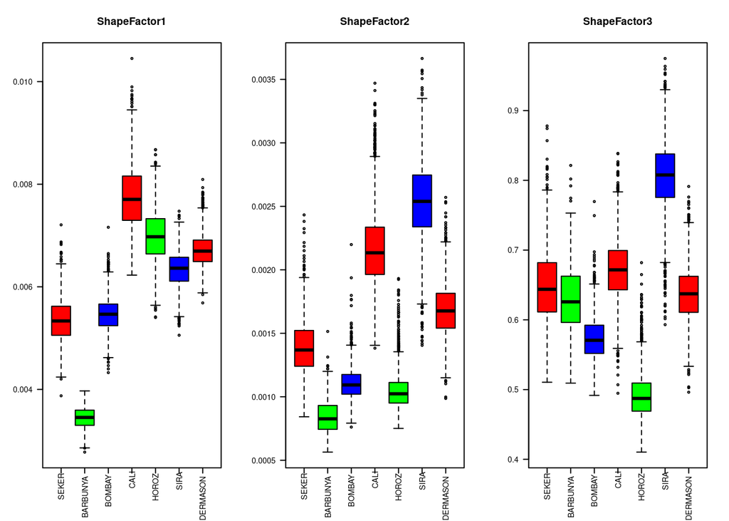

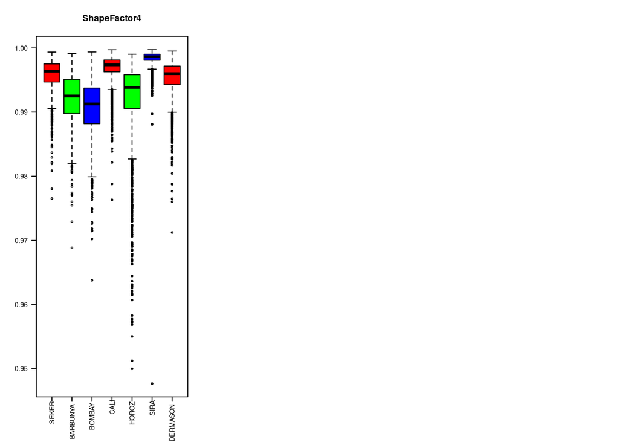

Analisando os boxplots gerados, é possível notar que as classes na variável **ShapeFactor2** apresentam maior distinção entre sí, já que a área entre o 1º e 3º quartil dos seus valores está menos linhada entre os quartis das classes se comparado com as demais variáveis. Portanto, é possivel concluir que a variável **ShapeFactor2** é a que mais apresenta poder de discriminação.

### 6 - Utilizando gráficos de densidade por variável (organize em 3 colunas), é possível fazer alguma afirmação sobre a discriminabilidade de alguma classe? Pode utilizar os boxplots gerados na etapa anterior para auxiliar nas conclusões.

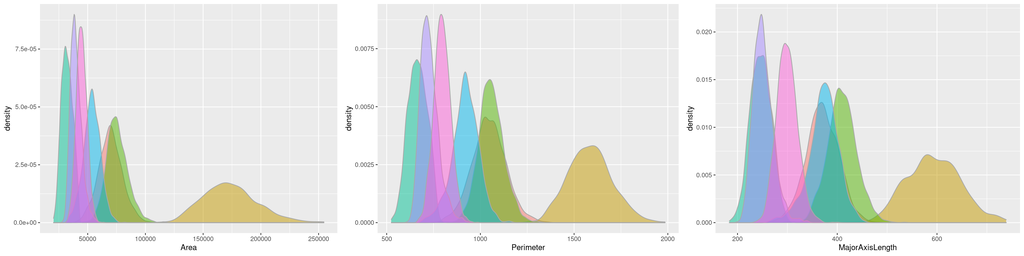

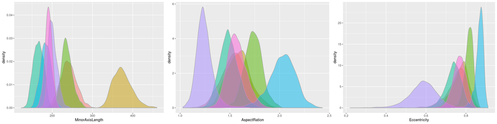

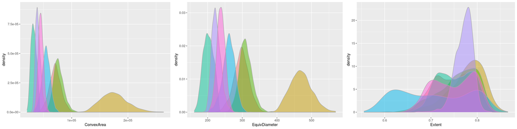

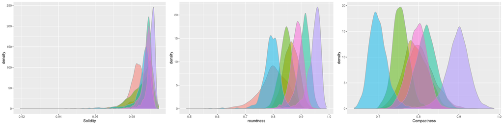

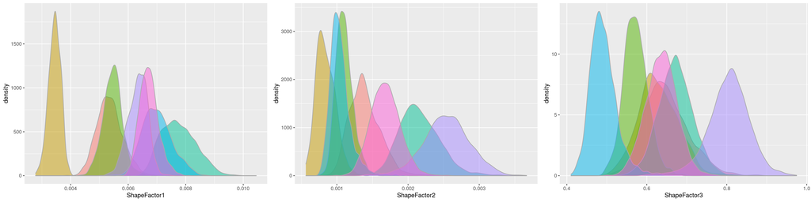

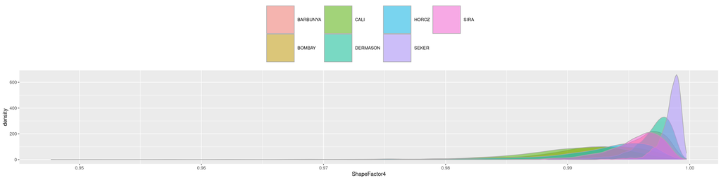

Com os gráfico de densidade, é possivel perceber que certas classes, no escopo de algumas variavéis especifícas, tem a grande maioria das observações sem contato com nenhuma outra curva de outras classes - por exemplo as instancias de classe **Bombay**, visualizando varivéis como **Area, Perimeter, MajorAxisLength, MinorAxisLength, ConvexArea, EquivDiameter e ShapeFactor1**.

Porém como elencado anteriormente, a variável que apresenta visualmente uma discriminação evidente é o **ShapeFactor2**. Pode ser destacado que as medianas de nenhuma caracteristica são alinhadas verticalmente, assim como à area referente ao primeiro desvio padrão da maioria das variavéis estão deslocadas e não se encontram.

### 7- Alguma variável (por classe) possui uma distribuição normal (curva do sino)? É possível verificar numericamente se é verdade?

Analisando os graficos de densidade gerados na questão 6, pontua-se que há varias variavéis dentro do escopo de classes que são distribuídas normalmente. Por exemplo, para a classe **Bombay**, tem as instâncias com mais váriaveis normalizadas: **Perimeter, MajorAxisLength, AspectRation, EquivDiameter, Roundness e ShapeFactor1**.

Possibilita-se ser verificado numericamente a normalidade, utilizando o teste de **Shapiro-Wilk**:

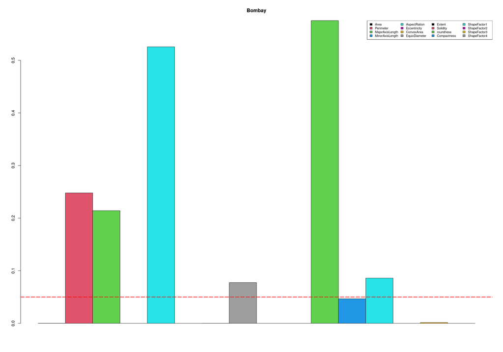

```r
  pvalue = c()
  for(i in 1:16){
    pvalue[i] = shapiro.test(beans_data[beans_data$Class=="BOMBAY",i])$p.value
  }
  barplot(pvalue, col = 1:16, space = c(0))
  title("Bombay")
  legend("topright", legend = names(beans_data)[1:16],ncol = 4,cex = 0.75, fill = 1:16)
  abline(h=0.05, col = "Red", lty = 5, lwd = 2)
```

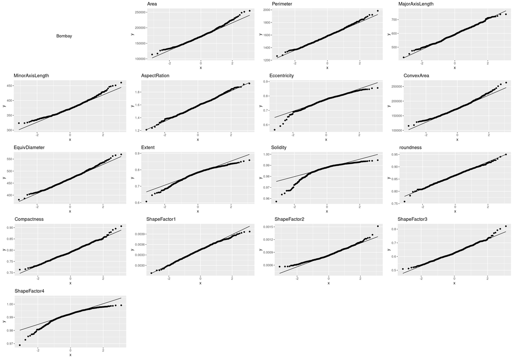

```r
p = list()
p[[1]] = textGrob("Bombay")
for(i in 2:17){

p[[i]] = ggplot(beans_data[beans_data$Class=="BOMBAY",], aes_string(sample=names(beans_data)[i - 1]),color="Class")+
  ggtitle(names(beans_data)[i - 1]) +
  stat_qq()+
  stat_qq_line()

}
do.call(grid.arrange,c(p))
```

```r
#ggpairs(beans_data, aes(colour = beans_data$Class, alpha = 0.4))
```

### 9- Após ter analisado estas informações, quais considerações você faz sobre este conjunto de dados (ou tarefa)?

O dataset de feijões é um conjunto de dados interessante de trabalhar, uma vez que apresenta variavéis com diferentes dimensões, o que força a termos cuidados maiores com a **plotagem** dos gráficos; número de classes maior que outros conjuntos introdutórios, por exemplo o da **iris** que contém apenas três classes, que nos dá maior variabilidade nos resultados das métricas analisadas - por exemplo normalidade e balanceamento. Além disso, o dataset, por possuir uma quantidade que pode ser considerada pequena de varíaveis, facilita a pesquisa e se torna curioso de trabalhar sobre, permitindo que apliquemos as técnicas de análise de dados vistas em aula de maneira que possamos reforçá-las e melhorar nossa familiaridade com as ferramentas relacionadas.